# Data Management Assignment

09/25/15

### Purpose of Study

While poverty and socioeconomic status are prime features in the increase of Heart Failure and other heart issues. This study will (1) observe the income, physical fitness, health conditions, and personal habits of the sample body; (2) determine if there is a direct link or not between socieconmic status and heart issues.

### Variables

Variables from AddHealthW4 that will be used include: `H4IR4` (Indicate the race of the sample member/respondent from your own observation), `H4EC1` (Income), `H4ID5E` (Heart Disease), `H4BDCL5` (Blood Pressure), `H4DA13` (How often the sample member physically exercises)

### Data Management

```r
library(PDS)
library(dplyr)
addhealth_public4.sub <- addhealth_public4 %>%
  filter(!is.na(h4ir4), !is.na(h4ec1), !is.na(h4bpcls), !is.na(h4id5e), !is.na(h4da13)) %>%
  select(h4ir4, h4ec1, h4bpcls, h4id5e, h4da13, h4gh7, bio_sex, h4gh6, h4to34, h4gh8)
dim(addhealth_public4.sub)
```

```
## [1] 5063   10
```

### Coding missing values

The variable `h4ec1` uses a 96 and 98 to record `unknown` for income of the sample population. A 6, 7, and 9 are used to record `unknown` for `h4bpcls` regarding the classification of blood pressure. Lastly, a 6 is used in the variable `h4id5e` to record the `unknown` for sample members answering if they have a heart condition.

```r
addhealth_public4.sub$h4ec1[addhealth_public4.sub$h4ec1 == 96 | addhealth_public4.sub$h4ec1 == 98] <- NA
summary(addhealth_public4.sub$h4ec1)
```

```
##    Min. 1st Qu.  Median    Mean 3rd Qu.    Max.    NA's
##   1.000   7.000   9.000   8.006  10.000  12.000     350
```

```r
addhealth_public4.sub$h4bpcls <- factor(addhealth_public4.sub$h4bpcls)[, drop = TRUE]
addhealth_public4.sub$h4bpcls[addhealth_public4.sub$h4bpcls == 6 | addhealth_public4.sub$h4bpcls == 7 | addhealth_public4.sub$h4bpcls == 9] <- NA
summary(addhealth_public4.sub$h4bpcls)
```

```
##    1    2    3    4    6    7    9 NA's
## 1716 2266  790  204    0    0    0   87
```

```r
summary(addhealth_public4.sub$h4ir4)
```

```
##    Min. 1st Qu.  Median    Mean 3rd Qu.    Max.
##   1.000   1.000   1.000   1.351   2.000   4.000
```

```r
addhealth_public4.sub$h4id5e[addhealth_public4.sub$h4id5e == 6] <- NA
addhealth_public4.sub$h4id5e <- factor(addhealth_public4.sub$h4id5e)[ , drop = TRUE]
summary(addhealth_public4.sub)
```

```
##      h4ir4           h4ec1           h4bpcls      h4id5e
##  Min.   :1.000   Min.   : 1.000   2      :2266   0   :5020
##  1st Qu.:1.000   1st Qu.: 7.000   1      :1716   1   :  42
##  Median :1.000   Median : 9.000   3      : 790   NA's:   1
##  Mean   :1.351   Mean   : 8.006   4      : 204
##  3rd Qu.:2.000   3rd Qu.:10.000   6      :   0
##  Max.   :4.000   Max.   :12.000   (Other):   0
##                  NA's   :350      NA's   :  87
##      h4da13           h4gh7         bio_sex          h4gh6
##  Min.   : 0.000   Min.   :1.00   Min.   :1.000   Min.   : 18.0
##  1st Qu.: 0.000   1st Qu.:3.00   1st Qu.:1.000   1st Qu.:150.0
##  Median : 0.000   Median :4.00   Median :2.000   Median :180.0
##  Mean   : 1.554   Mean   :3.62   Mean   :1.542   Mean   :196.7
##  3rd Qu.: 2.000   3rd Qu.:4.00   3rd Qu.:2.000   3rd Qu.:215.0
##  Max.   :97.000   Max.   :8.00   Max.   :6.000   Max.   :998.0
##
##      h4to34          h4gh8
##  Min.   : 5.00   Min.   :  0.00
##  1st Qu.:15.00   1st Qu.:  1.00
##  Median :17.00   Median :  2.00
##  Mean   :33.34   Mean   :  3.36
##  3rd Qu.:21.00   3rd Qu.:  3.00
##  Max.   :98.00   Max.   :998.00
##                  NA's   :29
```

```r
addhealth_public4.sub$h4da13[addhealth_public4.sub$h4da13 == 96 | addhealth_public4.sub$h4da13 == 97 | addhealth_public4.sub$h4da13 == 98] <- NA
addhealth_public4.sub$h4gh7[addhealth_public4.sub$h4gh7 == 6 | addhealth_public4.sub$h4gh7 == 8] <- NA
summary(addhealth_public4.sub$h4gh7)
```

```
##    Min. 1st Qu.  Median    Mean 3rd Qu.    Max.    NA's
##   1.000   3.000   4.000   3.619   4.000   5.000       2
```

```r
addhealth_public4.sub$bio_sex[addhealth_public4.sub$bio_sex == 6] <- NA
addhealth_public4.sub$h4gh6[addhealth_public4.sub$h4gh6 == 996 | addhealth_public4.sub$h4gh6 == 998] <- NA
addhealth_public4.sub$h4to34[addhealth_public4.sub$h4to34 == 96| addhealth_public4.sub$h4to34 == 97 | addhealth_public4.sub$h4to34 == 98] <- NA
addhealth_public4.sub$h4gh8[addhealth_public4.sub$h4gh8 == 996 | addhealth_public4.sub$h4gh8 == 998] <- NA
```

### Labeling Variables

In the next section of code, variables are labeled and levels of factors are given informative labels. The order of the levels is also rearranged for the variables `h4ir4`, `h4ec1`, `h4id5e`, and `h4bpcls`.

```r
library(Hmisc)
label(addhealth_public4.sub$h4ir4) <- "Sample Member Ethnicity"
label(addhealth_public4.sub$h4ec1) <- "Sample Member Income"
label(addhealth_public4.sub$h4id5e) <- "Diagnosed with Heart Disease"
label(addhealth_public4.sub$h4bpcls) <- "Blood pressure classification"
label(addhealth_public4.sub$h4da13) <- "Use of Physical Activity Centers per week"
label(addhealth_public4.sub$h4gh7) <- "Weight Classification"
label(addhealth_public4.sub$bio_sex) <- "Gender"
label(addhealth_public4.sub$h4gh6) <- "Weight in Pounds"
label(addhealth_public4.sub$h4to34) <- "Age When They Started Drinking"
label(addhealth_public4.sub$h4gh8) <- "Number of times Member ate Fast Food in A Week"
addhealth_public4.sub$h4id5e <- factor(addhealth_public4.sub$h4id5e, labels = c("no", "yes"))
addhealth_public4.sub$h4bpcls <- factor(addhealth_public4.sub$h4bpcls, labels = c("normal", "prehypertension", "hypertension I", "hypertension II")) #normal: systolic=120<, diastolic=80<
addhealth_public4.sub$h4ec1 <- factor(addhealth_public4.sub$h4ec1, labels = c("less than $5,000", "$5,000 to $9,999", "$10,000 to $14,999", "$15,000 to $19,999", "$20,000 to $24,999", "$25,000 to $29,999", "$30,000 to $39,999", "$40,000 to $49,999", "$50,000 to $74,999", "$75,000 to $99,999", "$100,000 to $149,999", "$150,000 or more"))
addhealth_public4.sub$h4ir4 <- factor(addhealth_public4.sub$h4ir4, labels = c("White", "African American", "Native American", "Asian"))
addhealth_public4.sub$h4gh7 <- factor(addhealth_public4.sub$h4gh7, labels = c("very underweight", "slightly underweight", "about the right weight", "slightly overweight", "very overweight"))
addhealth_public4.sub$bio_sex <- factor(addhealth_public4.sub$bio_sex, labels = c("male", "female"))
```

### Renaming Variables

```r
addhealth_public4.sub <- addhealth_public4.sub %>%
  rename(Race = h4ir4, BloodPressure = h4bpcls, HeartDisease = h4id5e, Income = h4ec1, PhysicalActivityPerWeek = h4da13, WeightClassification = h4gh7, Gender = bio_sex, Weight = h4gh6, AgeWhenStartedDrinking = h4to34, FastFood = h4gh8)
head(addhealth_public4.sub)
```

```
##               Race             Income   BloodPressure HeartDisease
## 1 African American $50,000 to $74,999 prehypertension           no
## 2 African American   less than $5,000 prehypertension           no
## 3            White $20,000 to $24,999 prehypertension           no
## 4            White $25,000 to $29,999 prehypertension           no
## 5 African American $50,000 to $74,999            <NA>           no
## 6            White $50,000 to $74,999 prehypertension           no
##   PhysicalActivityPerWeek   WeightClassification Gender Weight
## 1                       0        very overweight female    238
## 2                       3   slightly underweight   male    235
## 3                       0 about the right weight   male    145
## 4                       0    slightly overweight   male    200
## 5                       0        very overweight   male    325
## 6                       0 about the right weight   male    225
##   AgeWhenStartedDrinking FastFood
## 1                     16        6
## 2                     NA       28
## 3                     12        1
## 4                     18        2
## 5                     22        2
## 6                     NA       14
```

### Creating Tables

Basic tables can be created using the functions `table` or `xtabs`. Frequency tables are created for the variables `Race`, `BloodPressure`, `HeartDisease`, and `Income`.

```r
T1 <- xtabs(~Race, data = addhealth_public4.sub)
T2 <- xtabs(~BloodPressure, data = addhealth_public4.sub)
T3 <- xtabs(~HeartDisease, data = addhealth_public4.sub)
T4 <- xtabs(~Income, data = addhealth_public4.sub)
T5 <- xtabs(~PhysicalActivityPerWeek, data = addhealth_public4.sub)
T6 <- xtabs(~WeightClassification, data = addhealth_public4.sub)
T7 <- xtabs(~Weight, data = addhealth_public4.sub)
T8 <- xtabs(~FastFood, data = addhealth_public4.sub)
```

### Graphing Frequency Tables

The barplots are all created with the package `ggplot2`. The barplots start with the defaults for the `geom_bar` and add more detail to the plot with each graph.

```r
library(ggplot2)
g1 <- ggplot(data = addhealth_public4.sub, aes(x = Race)) +
  geom_bar(fill = "gold") +
  labs(x = "Race", y = "Total Number", title = "Sample Member Ethnicity") + theme_bw()
  theme(axis.text.x  = element_text(angle = 75, vjust = 0.5))
```

```
## List of 1
##  $ axis.text.x:List of 8
##   ..$ family    : NULL
##   ..$ face      : NULL
##   ..$ colour    : NULL
##   ..$ size      : NULL
##   ..$ hjust     : NULL
##   ..$ vjust     : num 0.5
##   ..$ angle     : num 75
##   ..$ lineheight: NULL
##   ..- attr(*, "class")= chr [1:2] "element_text" "element"
##  - attr(*, "class")= chr [1:2] "theme" "gg"
##  - attr(*, "complete")= logi FALSE
```

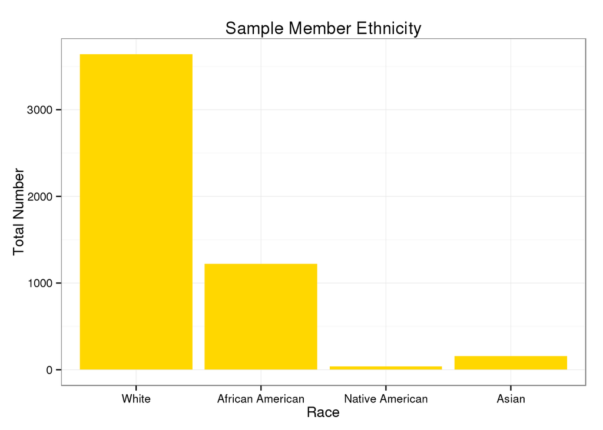

```r
g1
```

This bar graph depicts the ethnicities of the sample population as reported by the interviewers. The majority of the population interviewed were White, followed by African American, Asian and lastly, Native American.

```r
g2 <- ggplot(data = addhealth_public4.sub, aes(x = BloodPressure)) +
  geom_bar(fill = "blue") +
  labs(x = "Blood Pressure Type", y = "Total Number", title = "Blood Pressure Condition") + theme_bw()
  theme(axis.text.x  = element_text(angle = 75, vjust = 0.5))
```

```
## List of 1
##  $ axis.text.x:List of 8
##   ..$ family    : NULL
##   ..$ face      : NULL
##   ..$ colour    : NULL
##   ..$ size      : NULL
##   ..$ hjust     : NULL
##   ..$ vjust     : num 0.5
##   ..$ angle     : num 75
##   ..$ lineheight: NULL
##   ..- attr(*, "class")= chr [1:2] "element_text" "element"
##  - attr(*, "class")= chr [1:2] "theme" "gg"
##  - attr(*, "complete")= logi FALSE
```

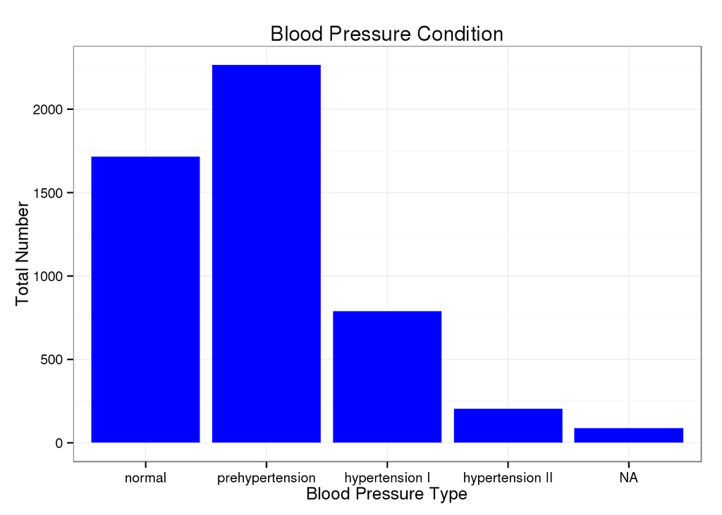

```r
g2
```

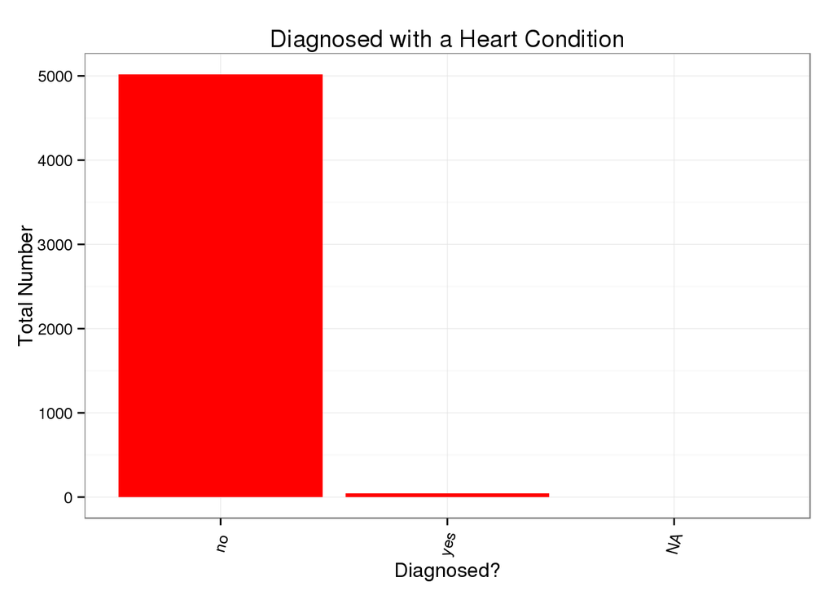

```r
g3 <- ggplot(data = addhealth_public4.sub, aes(x = HeartDisease)) +
  geom_bar(fill = "red") +
  labs(x = "Diagnosed?", y = "Total Number", title = "Diagnosed with a Heart Condition") +
  theme_bw() +
  theme(axis.text.x  = element_text(angle = 75, vjust = 0.5))
g3
```

This graph explicitly shows that most of the population has not been diagnosed with any heart conditions.

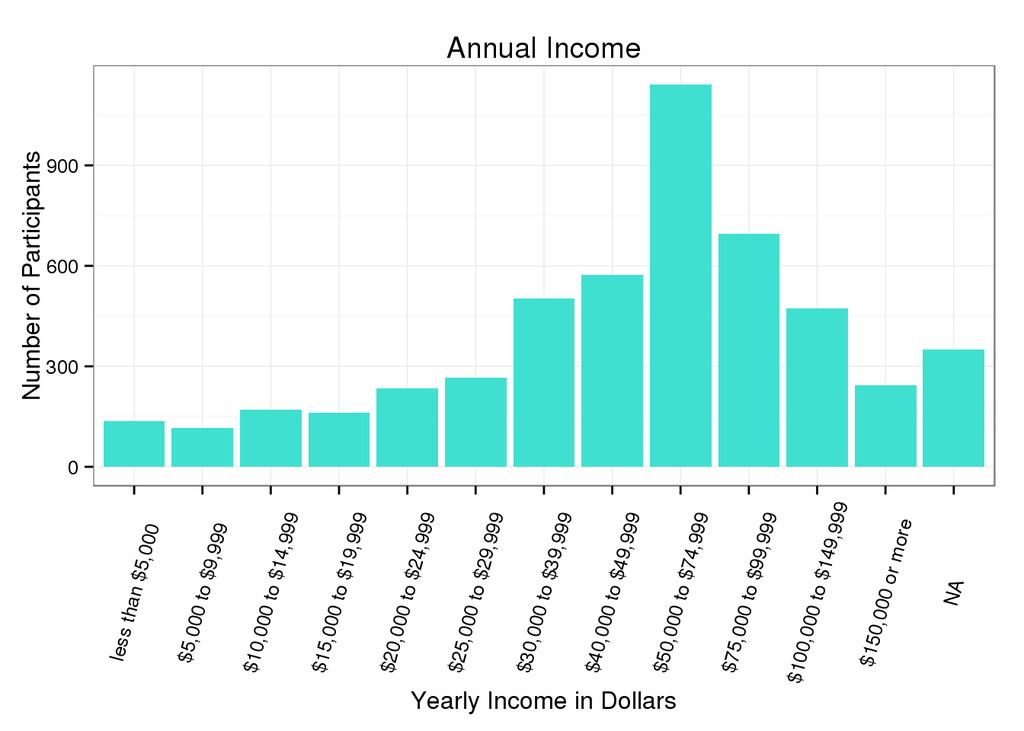

```r
g4 <- ggplot(data = addhealth_public4.sub, aes(x = Income)) +
    geom_bar(fill = "turquoise") +
    labs(x = "Yearly Income in Dollars", y = "Number of Participants", title = "Annual Income") +
    theme_bw() +
     theme(axis.text.x  = element_text(angle = 75, vjust = 0.5))
g4
```

### Graphing Numerical Variables

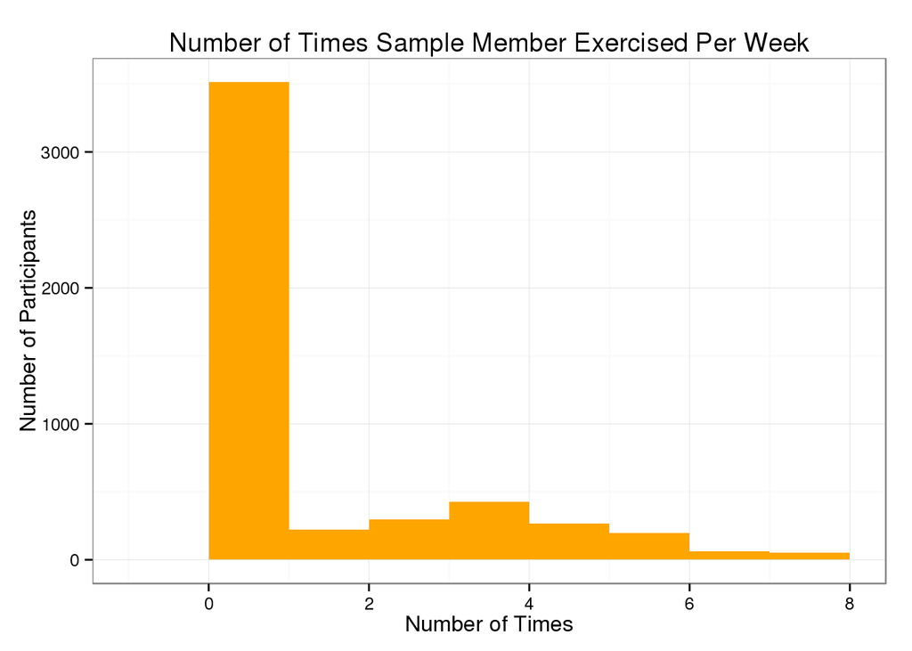

```r
ggplot(data = addhealth_public4.sub, aes(x = PhysicalActivityPerWeek)) +
  geom_histogram(binwidth = 1, fill = "orange") +
  labs(x = "Number of Times", y = "Number of Participants", title = "Number of Times Sample Member Exercised Per Week") +
  theme_bw()
```

### The 3 S’s

```r
summary(addhealth_public4.sub$PhysicalActivityPerWeek)
```

```
##    Min. 1st Qu.  Median    Mean 3rd Qu.    Max.    NA's
##  0.0000  0.0000  0.0000  0.9662  2.0000  7.0000      31
```

```r
fivenum(addhealth_public4.sub$PhysicalActivityPerWeek)
```

```
## Use of Physical Activity Centers per week
## [1] 0 0 0 2 7
```

```r
median(addhealth_public4.sub$PhysicalActivityPerWeek, na.rm = TRUE)
```

```
## [1] 0
```

```r
IQR(addhealth_public4.sub$PhysicalActivityPerWeek, na.rm = TRUE)
```

```
## [1] 2
```

## Graph

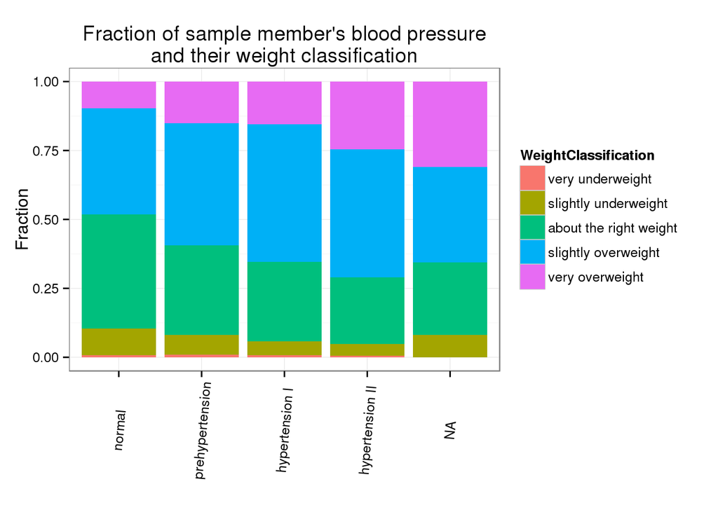

```r
library(ggplot2)
ggplot(data = addhealth_public4.sub, aes(x = BloodPressure, fill = WeightClassification)) +
  geom_bar(position = "fill") +
  theme_bw() +
  labs(x = "", y = "Fraction",
       title = "Fraction of sample member's blood pressure\nand their weight classification") +
  theme(axis.text.x  = element_text(angle = 85, vjust = 0.5))
```

## Graph

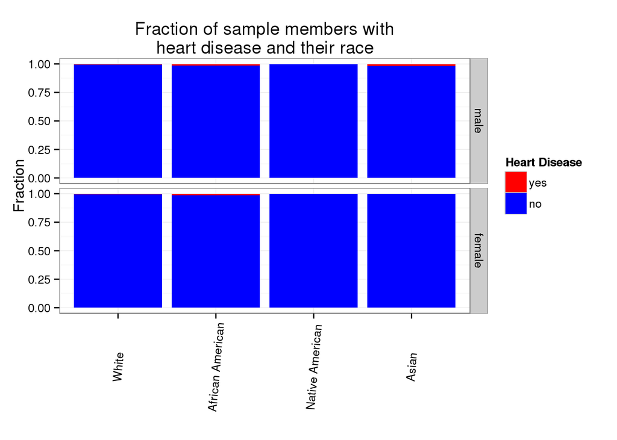

```r
ggplot(data = na.omit(addhealth_public4.sub), aes(x = Race, fill = HeartDisease)) +   geom_bar(position = "fill") +
  theme_bw() +
  labs(x = "", y = "Fraction",
       title = "Fraction of sample members with\nheart disease and their race") +
  scale_fill_manual(values = c("blue", "Red"), name = "Heart Disease") +
  guides(fill = guide_legend(reverse = TRUE)) +
  facet_grid(Gender~.) +
  theme(axis.text.x  = element_text(angle = 85, vjust = 0.5))
```

This graph shows the heart disease status of males and feamles of different ethnicities. It explicitly shows the reader that many individuals do not have heart disease, with African Americans having the most individuals with heart issues.

## ANOVA

I am comparing the number of times the particpants exercised per week, to their individual race.

Null hypothesis: There is no association between and individual’s race and the number of times they exercise per week.

Alternative hypothesis: There is an association between and individual’s race and the number of times they exercise per week.

```r
tapply(addhealth_public4.sub$PhysicalActivityPerWeek, addhealth_public4.sub$Race, mean, na.rm=TRUE)
```

```
##            White African American  Native American            Asian
##        0.9493253        0.9534497        1.3170732        1.3630573
```

```r
tapply(addhealth_public4.sub$PhysicalActivityPerWeek, addhealth_public4.sub$Race, sd, na.rm=TRUE)
```

```
##            White African American  Native American            Asian
##         1.678143         1.690581         2.184480         1.895179
```

### Box Plots

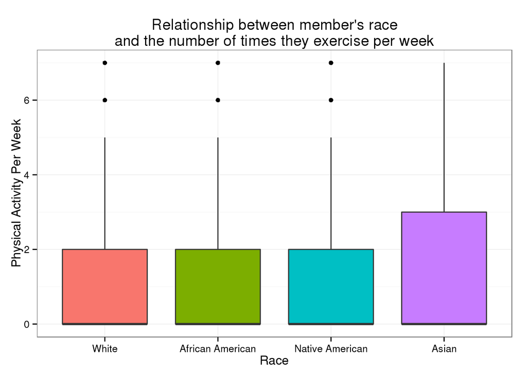

```r
library(ggplot2)
ggplot(data = addhealth_public4.sub, aes(x = Race, y = PhysicalActivityPerWeek, fill = Race)) +
  geom_boxplot() +
  theme_bw() +
  guides(fill = FALSE) +
  labs(x = "Race", y = "Physical Activity Per Week", title = "Relationship between member's race\nand the number of times they exercise per week")
```

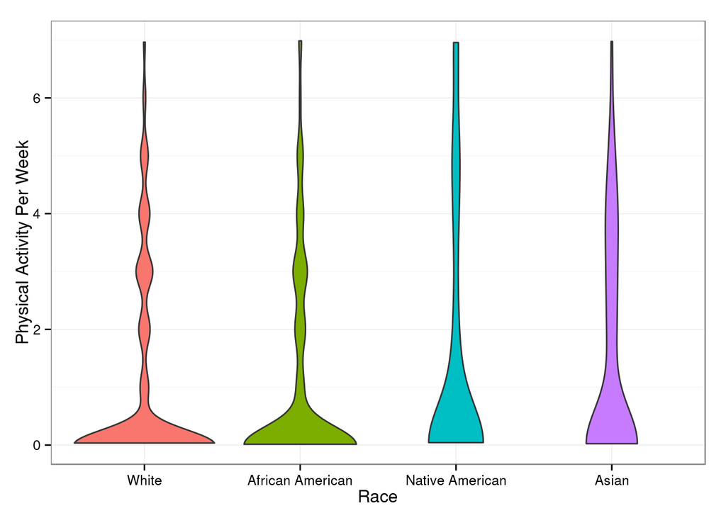

```r
ggplot(data = addhealth_public4.sub, aes(x = Race, y = PhysicalActivityPerWeek, fill = Race)) +
  geom_violin() +
  theme_bw() +
  guides(fill = FALSE) +
  labs(x = "Race", y = "Physical Activity Per Week")
```

```r
mod1 <- aov(PhysicalActivityPerWeek ~ Race, data = addhealth_public4.sub)
mod1
```

```
## Call:
##    aov(formula = PhysicalActivityPerWeek ~ Race, data = addhealth_public4.sub)
##
## Terms:
##                      Race Residuals
## Sum of Squares     31.004 14409.253
## Deg. of Freedom         3      5028
##
## Residual standard error: 1.692868
## Estimated effects may be unbalanced
## 31 observations deleted due to missingness
```

```r
summary(mod1)
```

```
##               Df Sum Sq Mean Sq F value Pr(>F)
## Race           3     31  10.335   3.606 0.0128 *
## Residuals   5028  14409   2.866
## ---
## Signif. codes:  0 '***' 0.001 '**' 0.01 '*' 0.05 '.' 0.1 ' ' 1
## 31 observations deleted due to missingness
```

```r
mod2 <- lm(PhysicalActivityPerWeek ~ Race, data = addhealth_public4.sub)
mod2
```

```
##
## Call:
## lm(formula = PhysicalActivityPerWeek ~ Race, data = addhealth_public4.sub)
##
## Coefficients:
##          (Intercept)  RaceAfrican American   RaceNative American
##             0.949325              0.004124              0.367748
##            RaceAsian
##             0.413732
```

```r
anova(mod2)
```

```
## Analysis of Variance Table
##
## Response: PhysicalActivityPerWeek
##             Df Sum Sq Mean Sq F value  Pr(>F)
## Race         3     31 10.3346  3.6062 0.01281 *
## Residuals 5028  14409  2.8658
## ---
## Signif. codes:  0 '***' 0.001 '**' 0.01 '*' 0.05 '.' 0.1 ' ' 1
```

```r
CIS <- TukeyHSD(mod1)
CIS
```

```
##   Tukey multiple comparisons of means
##     95% family-wise confidence level
##
## Fit: aov(formula = PhysicalActivityPerWeek ~ Race, data = addhealth_public4.sub)
##
## $Race
##                                         diff         lwr       upr
## African American-White           0.004124454 -0.14060109 0.1488500
## Native American-White            0.367747916 -0.31550907 1.0510049
## Asian-White                      0.413732070  0.05909851 0.7683656
## Native American-African American 0.363623462 -0.32728935 1.0545363
## Asian-African American           0.409607616  0.04043914 0.7787761
## Asian-Native American            0.045984154 -0.71702305 0.8089914
##                                      p adj
## African American-White           0.9998592
## Native American-White            0.5099622
## Asian-White                      0.0145040
## Native American-African American 0.5294118
## Asian-African American           0.0226750
## Asian-Native American            0.9986773
```

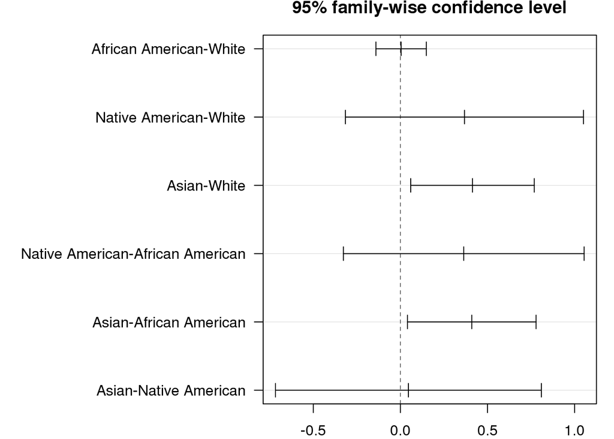

```r
opar <- par(no.readonly = TRUE)  # copy of current settings
par(mar =c(2, 15, 2, 1))
plot(CIS, las = 1)                       # restore original settings
```

```r
par(opar)
```

Due to the p-value being below 0.05, I would reject the null hypothesis that there is no association between the sample member’s race and the number of times they exercise per week. In the post hoc test, there were two values that were under 0.05: “Asian-White” and “Asian-Africa American.” Therefore there is a correlation between those variables.

## Chi Square Test of Independence

Null Hypothesis: There is no association between a sample member’s blood pressure and their gender. Alternative Hypothesis: There is an association between a sample member’s blood pressure and their gender.

```r
T1 <- xtabs(~Gender + BloodPressure, data = addhealth_public4.sub)
T1
```

```
##         BloodPressure
## Gender   normal prehypertension hypertension I hypertension II
##   male      378            1241            538             123
##   female   1338            1025            251              81
```

```r
T2 <- prop.table(T1, 2)
T2
```

```
##         BloodPressure
## Gender      normal prehypertension hypertension I hypertension II
##   male   0.2202797       0.5476611      0.6818758       0.6029412
##   female 0.7797203       0.4523389      0.3181242       0.3970588
```

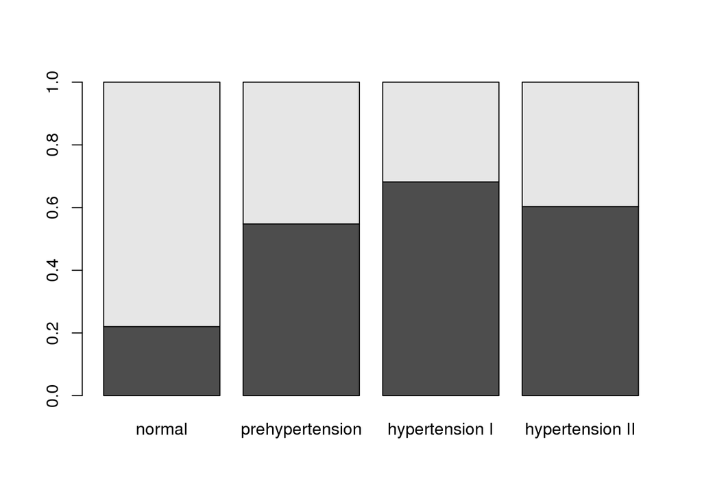

```r
barplot(T2)
```

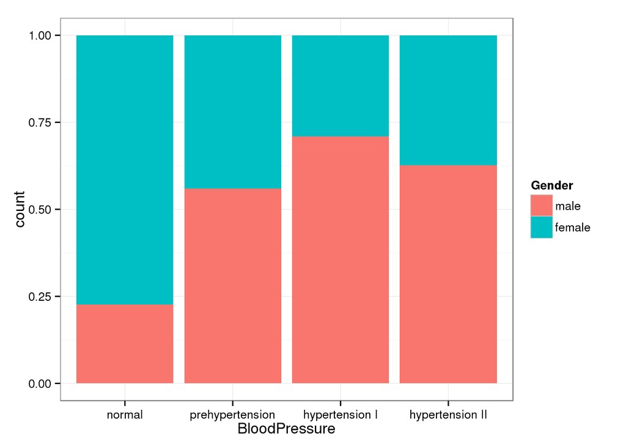

```r
library(ggplot2)
ggplot(data = na.omit(addhealth_public4.sub), aes(x = BloodPressure, fill = Gender)) +
  geom_bar(position = "fill") +
  theme_bw()
```

```r
chisq.test(T1)
```

```
##
##  Pearson's Chi-squared test
##
## data:  T1
## X-squared = 640.54, df = 3, p-value < 2.2e-16
```

When examining the association between gender (categorical response) and sample member’s blood pressure (categorical explanatory), a chi-square test of independence revealed that, females (my sample), were more likely to have normal blood pressure (77.97%) compared to males (22.03%), Ï‡2= 640.54, 3 df, p < 2.2e-16.

### Post Hoc Test

```r
NT <- xtabs(~ Gender + BloodPressure, data = addhealth_public4.sub)
NT
```

```
##         BloodPressure
## Gender   normal prehypertension hypertension I hypertension II
##   male      378            1241            538             123
##   female   1338            1025            251              81
```

```r
chisq.test(NT, correct = FALSE)
```

```
##
##  Pearson's Chi-squared test
##
## data:  NT
## X-squared = 640.54, df = 3, p-value < 2.2e-16
```

```r
chisq.test(NT[, c(1, 2)], correct = FALSE)
```

```
##
##  Pearson's Chi-squared test
##
## data:  NT[, c(1, 2)]
## X-squared = 433.79, df = 1, p-value < 2.2e-16
```

```r
chisq.test(NT[, c(1, 3)], correct = FALSE)
```

```
##
##  Pearson's Chi-squared test
##
## data:  NT[, c(1, 3)]
## X-squared = 496.49, df = 1, p-value < 2.2e-16
```

```r
chisq.test(NT[, c(1, 4)], correct = FALSE)
```

```
##
##  Pearson's Chi-squared test
##
## data:  NT[, c(1, 4)]
## X-squared = 138.44, df = 1, p-value < 2.2e-16
```

```r
chisq.test(NT[, c(2, 3)], correct = FALSE)
```

```
##
##  Pearson's Chi-squared test
##
## data:  NT[, c(2, 3)]
## X-squared = 43.343, df = 1, p-value = 4.593e-11
```

```r
chisq.test(NT[, c(2, 4)], correct = FALSE)
```

```
##
##  Pearson's Chi-squared test
##
## data:  NT[, c(2, 4)]
## X-squared = 2.3129, df = 1, p-value = 0.1283
```

```r
chisq.test(NT[, c(3, 4)], correct = FALSE)
```

```
##
##  Pearson's Chi-squared test
##
## data:  NT[, c(3, 4)]
## X-squared = 4.5379, df = 1, p-value = 0.03315
```

A Chi Square test of independence revealed that the sample member’s gender (my sample) and their blood pressure were significantly associated, Ï‡2 = 640.54, 3 df, p < 2.2e-16. Post hoc comparisons of the sample member’s gender and their blood pressure revealed that higher rates of blood pressure were among males.

### Correlation

I will be comparing the weight of the respondents and the year they started drinking to see if there is a correlation between the two.

Null Hypothesis: There is no association between the age the respondents started drinking and their weight. ALternative Hypothesis: There is an association between the age the respondents started drinking and their weight.

```r
library(PDS)
head(addhealth_public4.sub)
```

```
##               Race             Income   BloodPressure HeartDisease
## 1 African American $50,000 to $74,999 prehypertension           no
## 2 African American   less than $5,000 prehypertension           no
## 3            White $20,000 to $24,999 prehypertension           no
## 4            White $25,000 to $29,999 prehypertension           no
## 5 African American $50,000 to $74,999            <NA>           no
## 6            White $50,000 to $74,999 prehypertension           no
##   PhysicalActivityPerWeek   WeightClassification Gender Weight
## 1                       0        very overweight female    238
## 2                       3   slightly underweight   male    235
## 3                       0 about the right weight   male    145
## 4                       0    slightly overweight   male    200
## 5                       0        very overweight   male    325
## 6                       0 about the right weight   male    225
##   AgeWhenStartedDrinking FastFood
## 1                     16        6
## 2                     NA       28
## 3                     12        1
## 4                     18        2
## 5                     22        2
## 6                     NA       14
```

```r
plot(AgeWhenStartedDrinking ~ Weight, data = addhealth_public4.sub)
mod <- lm(AgeWhenStartedDrinking ~ Weight, data = addhealth_public4.sub)
summary(mod)
```

```
##
## Call:
## lm(formula = AgeWhenStartedDrinking ~ Weight, data = addhealth_public4.sub)
##
## Residuals:
## Age When They Started Drinking
##      Min       1Q   Median       3Q      Max
## -11.5009  -1.3413   0.0601   1.5499  16.5464
##
## Coefficients:
##               Estimate Std. Error t value Pr(>|t|)
## (Intercept) 16.6239449  0.1962655  84.701   <2e-16 ***
## Weight      -0.0009462  0.0010329  -0.916     0.36
## ---
## Signif. codes:  0 '***' 0.001 '**' 0.01 '*' 0.05 '.' 0.1 ' ' 1
##
## Residual standard error: 3.152 on 3948 degrees of freedom
##   (1113 observations deleted due to missingness)
## Multiple R-squared:  0.0002125,  Adjusted R-squared:  -4.074e-05
## F-statistic: 0.8391 on 1 and 3948 DF,  p-value: 0.3597
```

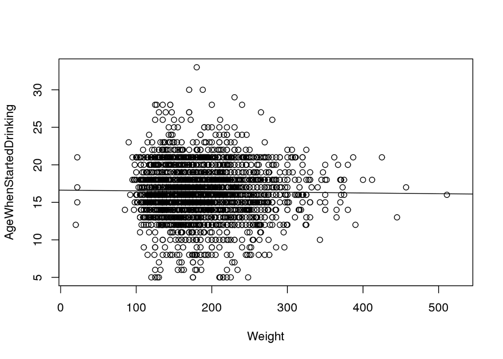

```r
abline(mod)
```

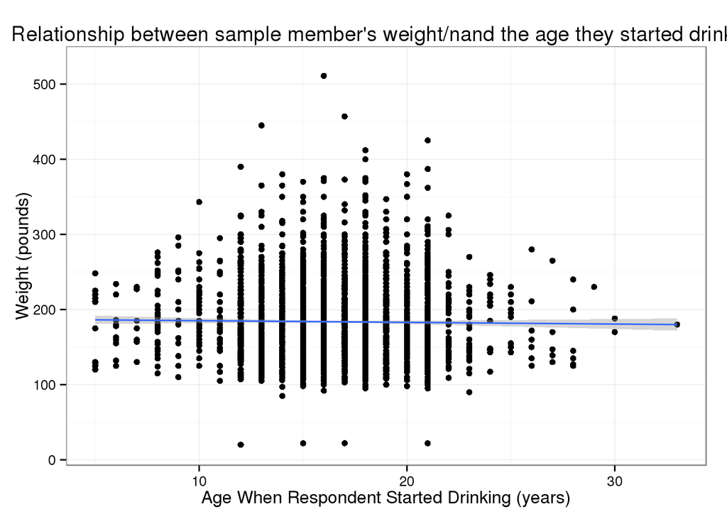

```r
library(ggplot2)
 ggplot(data = addhealth_public4.sub, aes(x = AgeWhenStartedDrinking, y = Weight)) +
  geom_point(color = "black") +
  theme_bw() +
  labs(x = "Age When Respondent Started Drinking (years)", y = "Weight (pounds)", title = "Relationship between sample member's weight/nand the age they started drinking") +
 stat_smooth(method = lm)
```

There is neither a positive or negative direction in the graph. The strength is weak as it has a negative correlation of -0.01457733. Since the value is close to zero, it has a weak linear relationship. There are a few outliers as some respondents are either very overweight, or very underweight.

```r
 cor(addhealth_public4.sub$Weight, addhealth_public4.sub$AgeWhenStartedDrinking)
```

```
## [1] NA
```

```r
 cor.test(addhealth_public4.sub$AgeWhenStartedDrinking, addhealth_public4.sub$Weight)
```

```
##
##  Pearson's product-moment correlation
##
## data:  addhealth_public4.sub$AgeWhenStartedDrinking and addhealth_public4.sub$Weight
## t = -0.91604, df = 3948, p-value = 0.3597
## alternative hypothesis: true correlation is not equal to 0
## 95 percent confidence interval:
##  -0.04574354  0.01661723
## sample estimates:
##         cor
## -0.01457733
```

### Regression

I am comparing the weight of the sample member’s and how many times per week they dine out at fast food restaurants

$H_0:\beta_{1} =0$ versus $H_A:\beta_{1} \neq 0$

Null Hypothesis: The slope of the line will be zero when comparing the sample member’s weight and how many times they eat fast food per week. Alternative Hypothesis: The slope of the line will not be equal to zero when compaing the sample member’s weight and how many times they eat fast food per week.

```r
library(PDS)
plot(FastFood ~ Weight, data = addhealth_public4.sub)
mod <- lm(FastFood ~ Weight, data = addhealth_public4.sub)
summary(mod)
```

[output not shown]

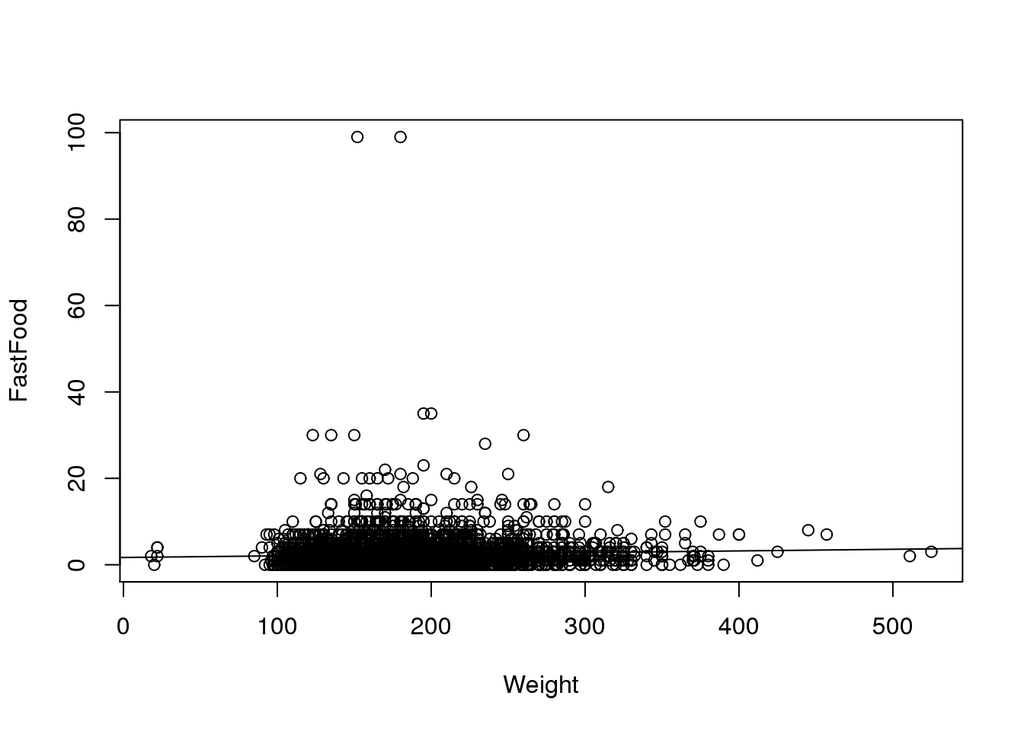

```r
abline(mod)
```

```r
cor(addhealth_public4.sub$Weight, addhealth_public4.sub$FastFood)
```

```
## [1] NA
```

```r
cor.test(addhealth_public4.sub$Weight, addhealth_public4.sub$FastFood)
```

```
##
##  Pearson's product-moment correlation
##
## data:  addhealth_public4.sub$Weight and addhealth_public4.sub$FastFood
## t = 3.823, df = 4950, p-value = 0.0001334
## alternative hypothesis: true correlation is not equal to 0
## 95 percent confidence interval:
##  0.02644456 0.08198733
## sample estimates:
##        cor
## 0.05425791
```

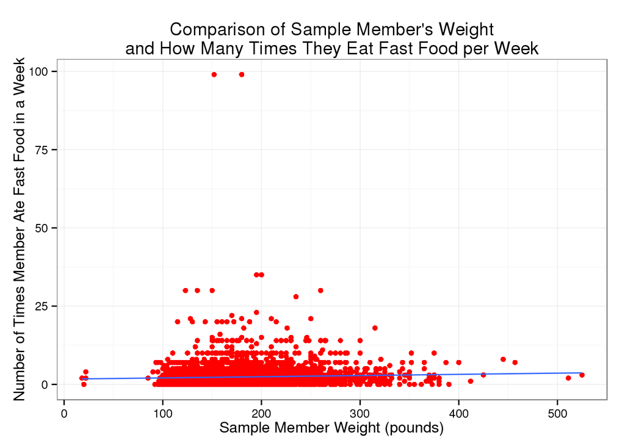

```r
library(grid)
library(ggplot2)
ggplot(data = addhealth_public4.sub, aes(x = Weight, y = FastFood)) +
   geom_point(color = "Red") +
   theme_bw() +
   labs(x = "Sample Member Weight (pounds)", y = "Number of Times Member Ate Fast Food in a Week", title = "Comparison of Sample Member's Weight\nand How Many Times They Eat Fast Food per Week") +
   geom_smooth(method = lm, se = FALSE)
```

Number of times sample member ate fast food per week = 0.0037988*x + 1.683174